# peril_kidney KO vs WT (Embryonic)

# questions

- overdispersion
- how do we rescale these plots? or just axes?
- add labels, descriptions
- turn off all caching
- general figure formatting/table formatting
- other heatmap labels (csHeatmap)

# Design Overview

This file shows the wt-v-ko comparison for peril_kidney.

Samples used are:

[output not shown]

Cuff overview:

```
## CuffSet instance with:
##   2 samples
##   31926 genes
##   77340 isoforms
##   45508 TSS
##   0 CDS
##   31926 promoters
##   45508 splicing
##   0 relCDS
```

## Replicates

|  | file | sample_name | replicate | rep_name | total_mass | norm_mass | internal_scale | external_scale |
| --- | --- | --- | --- | --- | --- | --- | --- | --- |
| 1 | /n/rinn_data1/users/agroff/seq/PERIL/data/bams/Sample_JR722_Peril_L43_E14-5_kidney_both_lobeswtM1_ACTGAT/accepted_hits.bam | wt | 0 | wt_0 | 32567800.00 | 28714000.00 | 1.13 | 1.00 |
| 2 | /n/rinn_data1/users/agroff/seq/PERIL/data/bams/Sample_JR723_Peril_L43_E14-5_kidney_both_lobes_wtf3_AGTCAA/accepted_hits.bam | wt | 1 | wt_1 | 24846400.00 | 28714000.00 | 0.88 | 1.00 |
| 3 | /n/rinn_data1/users/agroff/seq/PERIL/data/bams/Sample_JR725_Peril_L43_E14-5_kidney_both_lobes_wtm8_ATGTCA/accepted_hits.bam | wt | 2 | wt_2 | 18152700.00 | 28714000.00 | 0.61 | 1.00 |
| 4 | /n/rinn_data1/users/agroff/seq/PERIL/data/bams/Sample_JR724_Peril_L43_E14-5_kidney_both_lobes_kom7_AGTTCC/accepted_hits.bam | ko | 0 | ko_0 | 21233900.00 | 28714000.00 | 0.75 | 1.00 |
| 5 | /n/rinn_data1/users/agroff/seq/PERIL/data/bams/Sample_JR726_Peril_L43_E14-5_kidney_both_lobes_kof9_CCGTCC/accepted_hits.bam | ko | 1 | ko_1 | 41738700.00 | 28714000.00 | 1.43 | 1.00 |
| 6 | /n/rinn_data1/users/agroff/seq/PERIL/data/bams/Sample_JR727_Peril_L43_E14-5_kidney_both_lobes_kof10_ATTCCT/accepted_hits.bam | ko | 2 | ko_2 | 43552300.00 | 28714000.00 | 1.52 | 1.00 |

# QC

## Dispersion

This shows count (WHAT IS COUNT? fragment counts? per gene?) vs dispersion (of those counts), or the spread in measurements for a particular gene across replicates.

from cummerbund manual: Overdispersion is a common problem in RNA-Seq data. As of cufflinks v2.0 mean counts, variance, and dispersion are all emitted, allowing you to visualize the estimated overdispersion for each sample as a quality control measure. - See more at: http://compbio.mit.edu/cummeRbund/manual_2_0.html#sthash.9YRYxwRV.dpuf

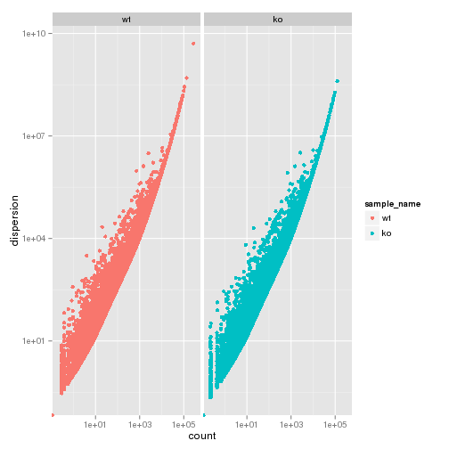

## Cross-replicate variability (fpkmSCVplot)

The squared coefficient of variation is a normalized measure of cross replicate variability that can be useful for evaluating the quality your RNA-seq data. Differences in CV 2 can result in lower numbers of differentially expressed genes due to a higher degree of variability between replicate fpkm estimates.

Genes:

```
## geom_smooth: method="auto" and size of largest group is >=1000, so using gam with formula: y ~ s(x, bs = "cs"). Use 'method = x' to change the smoothing method.
```

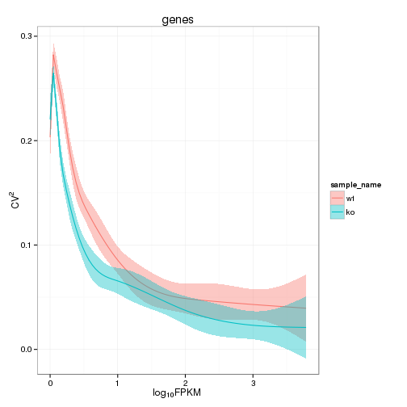

Isoforms:

```
## geom_smooth: method="auto" and size of largest group is >=1000, so using gam with formula: y ~ s(x, bs = "cs"). Use 'method = x' to change the smoothing method.
```

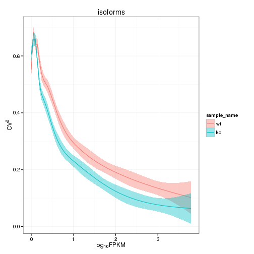

## Volcano

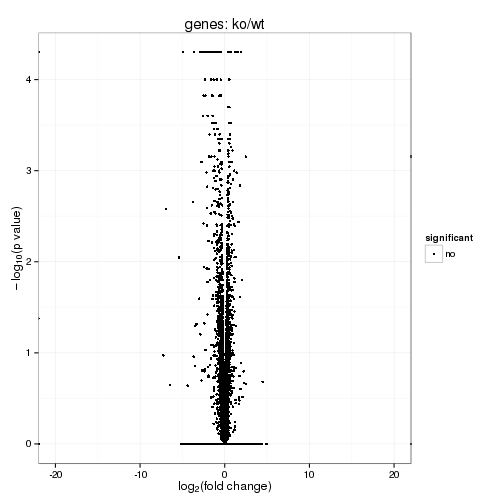

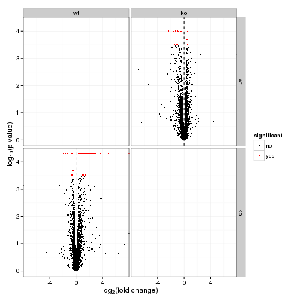

## MvA plot

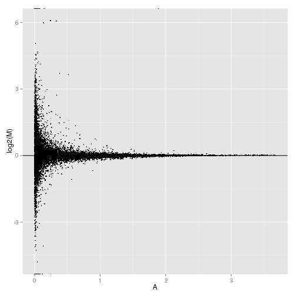

### MvA plot counts

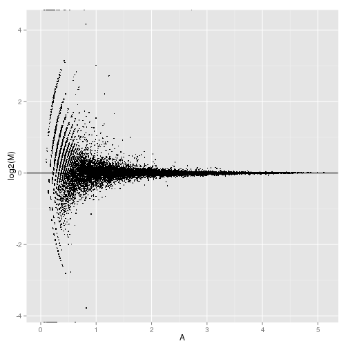

## Scatterplot

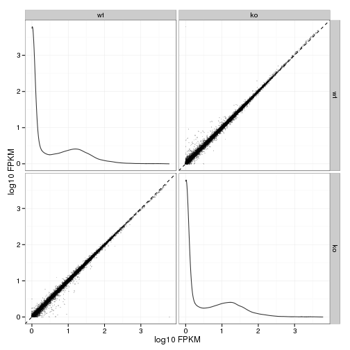

### Scatter matrix (replicates)

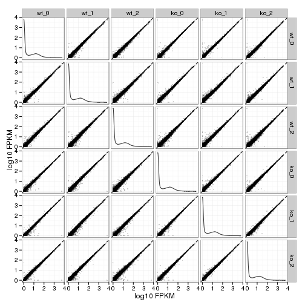

## Distributions

### Boxplot

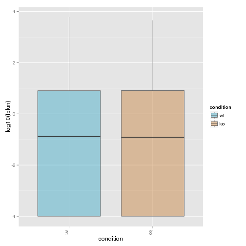

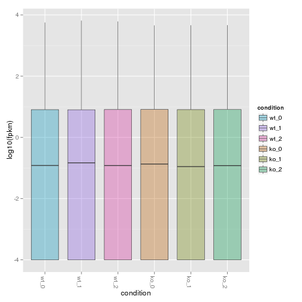

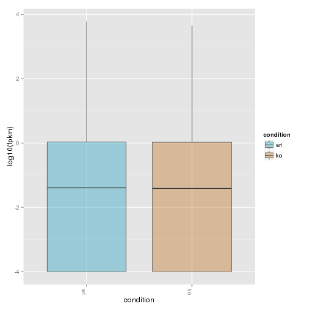

### Density

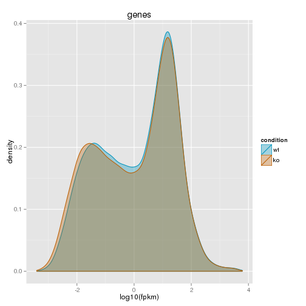

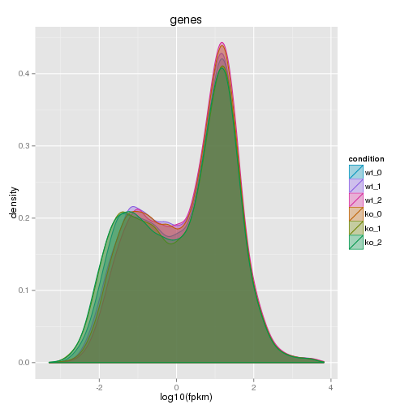

## Clustering

### Replicate Clusters

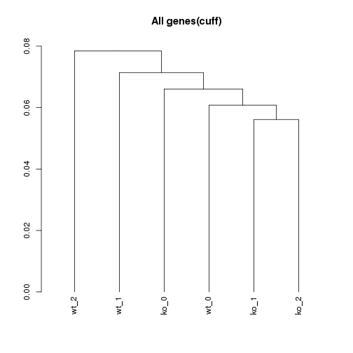

```
## 'dendrogram' with 2 branches and 6 members total, at height 0.07842
```

### PCA

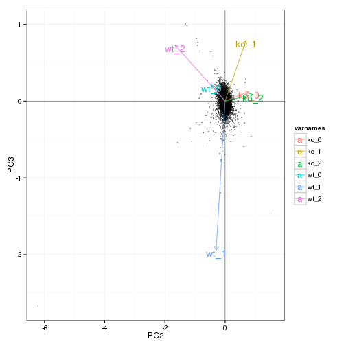

### MDS

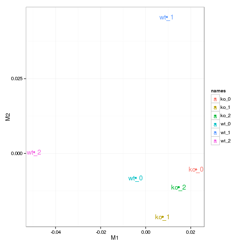

### Distance Heat Map

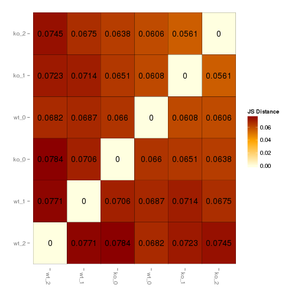

# KO assessment

## Endogenous lncRNA expression

[output not shown]

|  | gene_id | sample_name | fpkm | conf_hi | conf_lo | quant_status |
| --- | --- | --- | --- | --- | --- | --- |
| 1 | XLOC_008094 | ko | 1.68 | 2.21 | 1.14 | OK |
| 2 | XLOC_008094 | wt | 1.77 | 2.41 | 1.13 | OK |

|  | isoform_id | sample_name | fpkm | conf_hi | conf_lo | quant_status |
| --- | --- | --- | --- | --- | --- | --- |
| 1 | TCONS_00019669 | ko | 0.05 | 0.18 | 0.00 | OK |
| 2 | TCONS_00019670 | ko | 0.00 | 0.03 | 0.00 | OK |
| 3 | TCONS_00019671 | ko | 0.00 | 0.02 | 0.00 | OK |
| 4 | TCONS_00019672 | ko | 0.38 | 0.76 | 0.00 | OK |
| 5 | TCONS_00019673 | ko | 0.00 | 0.02 | 0.00 | OK |
| 6 | TCONS_00019674 | ko | 1.04 | 1.53 | 0.56 | OK |
| 7 | TCONS_00019675 | ko | 0.10 | 0.29 | 0.00 | OK |
| 8 | TCONS_00019676 | ko | 0.00 | 0.07 | 0.00 | OK |
| 9 | TCONS_00019677 | ko | 0.11 | 0.37 | 0.00 | OK |
| 10 | TCONS_00019669 | wt | 0.23 | 0.62 | 0.00 | OK |
| 11 | TCONS_00019670 | wt | 0.00 | 0.03 | 0.00 | OK |
| 12 | TCONS_00019671 | wt | 0.00 | 0.02 | 0.00 | OK |
| 13 | TCONS_00019672 | wt | 0.19 | 0.46 | 0.00 | OK |
| 14 | TCONS_00019673 | wt | 0.47 | 0.84 | 0.11 | OK |
| 15 | TCONS_00019674 | wt | 0.68 | 1.05 | 0.32 | OK |
| 16 | TCONS_00019675 | wt | 0.08 | 0.25 | 0.00 | OK |
| 17 | TCONS_00019676 | wt | 0.00 | 0.07 | 0.00 | OK |
| 18 | TCONS_00019677 | wt | 0.12 | 0.56 | 0.00 | OK |

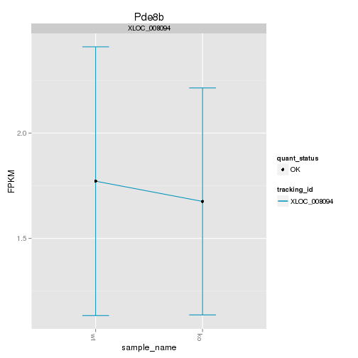

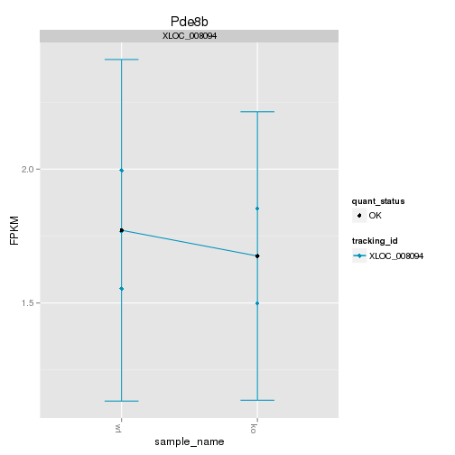

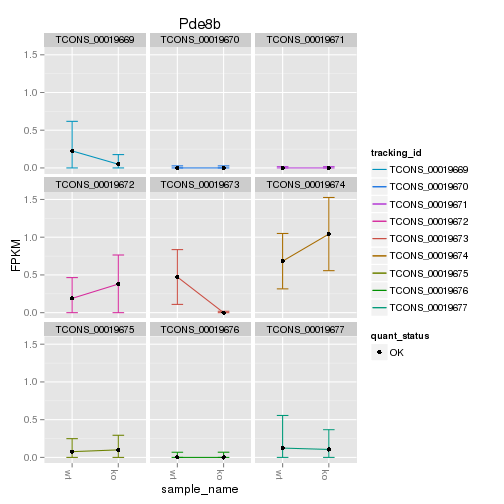

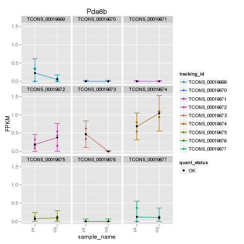

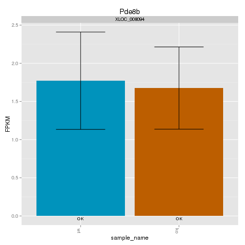

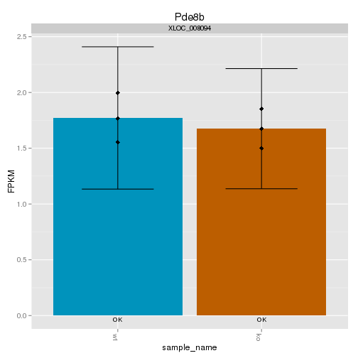

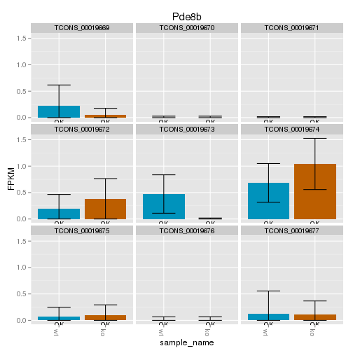

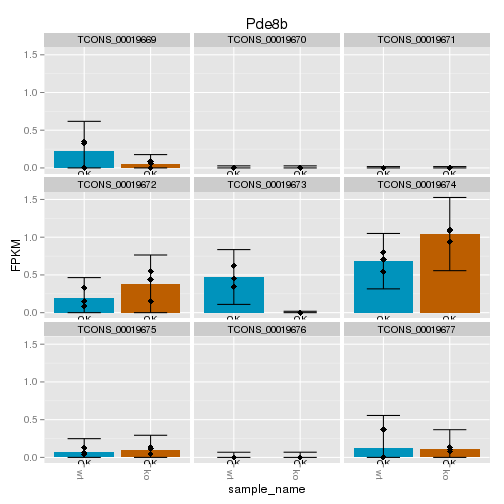

[output not shown]

[output not shown]

[output not shown]

[figure not shown]

[figure not shown]

[figure not shown]

[figure not shown]

```
## ymax not defined: adjusting position using y instead
```

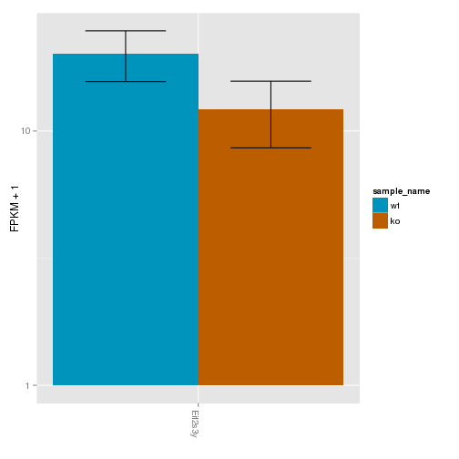

```
## ymax not defined: adjusting position using y instead
```

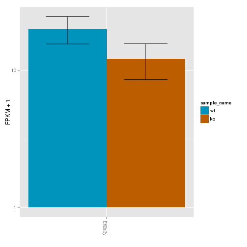